# The Effect of Types of Posts on Facebook during Election - Taking 柯文哲(Ke) as Example

Stego

2019.4.9

During the election, for politician, Facebook becomes an important instrument to convey their political views and policies. Candidates spent more and more money on the promulgation on Facebook. In this case, I will look into the Facebook fan pages of internet celebrity (politician), 柯文哲 (Ke), to see the effect of different types of posts.

## Load Files

```r
allData = data.frame()
for(fid in c(1:9))
{
  filename = paste0("20180",as.character(fid),"_data.csv")
  tempData = data.table::fread(filename, data.table = F,encoding = 'UTF-8')
  allData = rbind(allData, tempData)
}
for (fid in c(10:11))
{
  filename = paste0("2018",as.character(fid),"_data.csv")
  tempData = data.table::fread(filename, data.table = F,encoding = 'UTF-8')
  allData = rbind(allData, tempData)
}

allData$Date_day <- as.numeric(as.Date(allData$Date))
allData$Type <- as.factor(allData$Type)
```

## Scanning through Data

```r
KP <- subset(allData, Page_Name == "柯文哲")
summary(KP)
```

```
##      Date            Page_Name            Page_ID
##  Length:562         Length:562         Min.   :136845026417486
##  Class :character   Class :character   1st Qu.:136845026417486
##  Mode  :character   Mode  :character   Median :136845026417486
##                                        Mean   :287408799345428
##                                        3rd Qu.:543656759040101
##                                        Max.   :543656759040101
##
##    Link             Type     All_Reaction_Count   LIKE_COUNT
##  Mode:logical   album :  0   Min.   :     0.0   Min.   :     0.0
##  NA's:562       event :  0   1st Qu.:   290.2   1st Qu.:   271.2
##                 link  : 60   Median : 11363.5   Median : 10941.5
##                 note  :  0   Mean   : 20922.6   Mean   : 19538.3
##                 photo :204   3rd Qu.: 24581.5   3rd Qu.: 23243.0
##                 status: 18   Max.   :514742.0   Max.   :477862.0
##                 video :280
##    WOW_COUNT         LOVE_COUNT        HAHA_COUNT        SAD_COUNT
##  Min.   :   0.00   Min.   :    0.0   Min.   :    0.0   Min.   :    0.00
##  1st Qu.:   1.00   1st Qu.:    4.0   1st Qu.:    1.0   1st Qu.:    0.00
##  Median :  22.00   Median :  296.0   Median :   31.5   Median :    2.00
##  Mean   :  66.36   Mean   :  875.8   Mean   :  293.1   Mean   :   66.55
##  3rd Qu.:  61.00   3rd Qu.:  741.5   3rd Qu.:  161.2   3rd Qu.:    8.00
##  Max.   :3735.00   Max.   :36336.0   Max.   :14919.0   Max.   :12814.00
##
##   ANGRY_COUNT      Comment_Count       Share_Count        Message
##  Min.   :    0.0   Min.   :     0.0   Min.   :    0.0   Length:562
##  1st Qu.:    1.0   1st Qu.:     8.0   1st Qu.:    6.0   Class :character
##  Median :    8.0   Median :   305.0   Median :  218.5   Mode  :character
##  Mean   :   46.3   Mean   :  2103.5   Mean   :  681.9
##  3rd Qu.:   20.0   3rd Qu.:   933.5   3rd Qu.:  485.5
##  Max.   :11390.0   Max.   :125031.0   Max.   :25297.0
##
##   Link_Title        Link Description    created_time
##  Length:562         Length:562         Min.   :1514739874000
##  Class :character   Class :character   1st Qu.:1525086983000
##  Mode  :character   Mode  :character   Median :1534909052000
##                                        Mean   :1532663691759
##                                        3rd Qu.:1540699413000
##                                        Max.   :1543585397000
##
##     Date_day
##  Min.   :17532
##  1st Qu.:17651
##  Median :17765
##  Mean   :17739
##  3rd Qu.:17832
##  Max.   :17865
##
```

By summarying the data, we find out that there could be some posts revised repeatedly or deleted, resulting in similar meaning posts or zero context posts in very low (nearly 0) reactions. The misleading imformation would pull our reaction counts down, leading to a lower result.

## Grouping Data

In order to solve the problem previously mentioned, I suggest a plausible assumption: the post being revised or reposted would be done in the very same day. Hence, finding out the maximum reaction counts of the day could represent the very same post. Additionally, for every additional post in a day, the average engagement rate drops. That is, even though there could be more than one post a day, the effect would drop marginally.

Since the ranges of reaction counts are wide, I would tranfer the counts into a “log” form. Furthermore, to avoid negative infinity in log, I tranfer all the zero to one.

```r
KP <- allData %>%
  subset(Page_Name=="柯文哲") %>%
  group_by(Page_Name, Type, Date_day) %>%
  summarise(All_reaction = log(max(All_Reaction_Count)), log_Comment = log(max(Comment_Count)), log_Share = max(log(Share_Count))) %>%
  mutate(All_Reaction = ifelse(All_reaction==-Inf, 0, All_reaction), log_comment=ifelse(log_Comment==-Inf, 0, log_Comment) , log_share = ifelse(log_Share==-Inf, 0, log_Share)) %>%
  select(-All_reaction,-log_Comment, -log_Share)

summary(KP)
```

```
##   Page_Name             Type        Date_day      All_Reaction
##  Length:405         album :  0   Min.   :17532   Min.   : 0.000
##  Class :character   event :  0   1st Qu.:17640   1st Qu.: 6.100
##  Mode  :character   link  : 45   Median :17732   Median : 9.530
##                     note  :  0   Mean   :17723   Mean   : 8.605
##                     photo :164   3rd Qu.:17810   3rd Qu.:10.252
##                     status: 17   Max.   :17865   Max.   :13.151
##                     video :179
##   log_comment       log_share
##  Min.   : 0.000   Min.   : 0.000
##  1st Qu.: 2.708   1st Qu.: 2.303
##  Median : 5.916   Median : 5.606
##  Mean   : 5.154   Mean   : 4.726
##  3rd Qu.: 6.856   3rd Qu.: 6.460
##  Max.   :11.736   Max.   :10.138
##
```

## Visualization

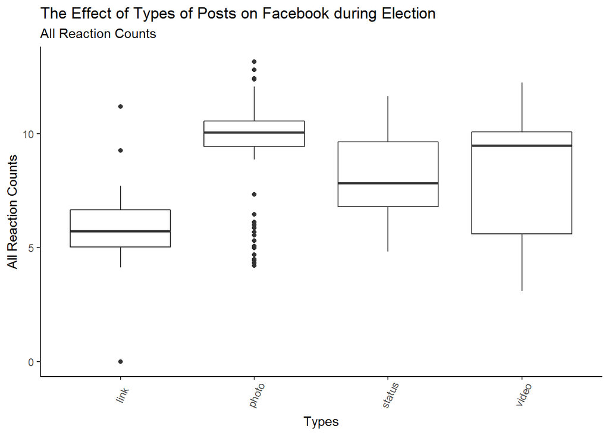

```r
K_reaction <- ggplot(KP, aes(x = Type, y = All_Reaction)) +geom_boxplot()+
  theme(axis.text.x = element_text(angle=65, vjust=0.6)) +
  labs(title="The Effect of Types of Posts on Facebook during Election",
       subtitle="All Reaction Counts",
       x="Types",
       y="All Reaction Counts")

K_reaction
```

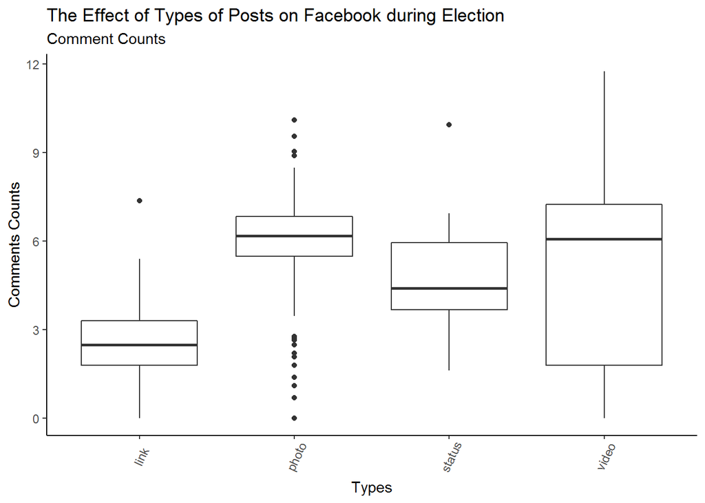

```r
K_comment <- ggplot(KP, aes(x = Type, y = log_comment)) +geom_boxplot()+
  theme(axis.text.x = element_text(angle=65, vjust=0.6)) +
  labs(title="The Effect of Types of Posts on Facebook during Election",
       subtitle="Comment Counts",
       x="Types",
       y="Comments Counts")

K_comment
```

[figure not shown]

```r
K_share <- ggplot(KP, aes(x = Type, y = log_share)) +geom_boxplot()+
  theme(axis.text.x = element_text(angle=65, vjust=0.6)) +
  labs(title="The Effect of Types of Posts on Facebook during Election",
       subtitle="Share Counts",
       x="Types",
       y="Share Counts")

K_share
```

Result:

Considering only reaction counts, photo type of post has a distinguished effect, meanwhile the average of video post shouldn’t be neglected. Regarding on the comment counts, both photo and video post have a more outstanding effect comparing with others. Sharing counts on Facebook sometimes are held as the most effective way in marketing, since one should be very fond of the post to share it on personal pages. In this case, photo and video posts encounter huge success.

Finally, the result shows that in Ke’s fan page, photo and video posts are a better way in marketing. In my opinion, the reason can be possibly attributed to the marketing trend on Internet. To elaborate, Ke’s targets often highly expose themselves in Internet. Hence, photo and video could be more eye-catching, standing out from wordy posts.